# Red Wine Quality Exploration

### Fixed Acidity

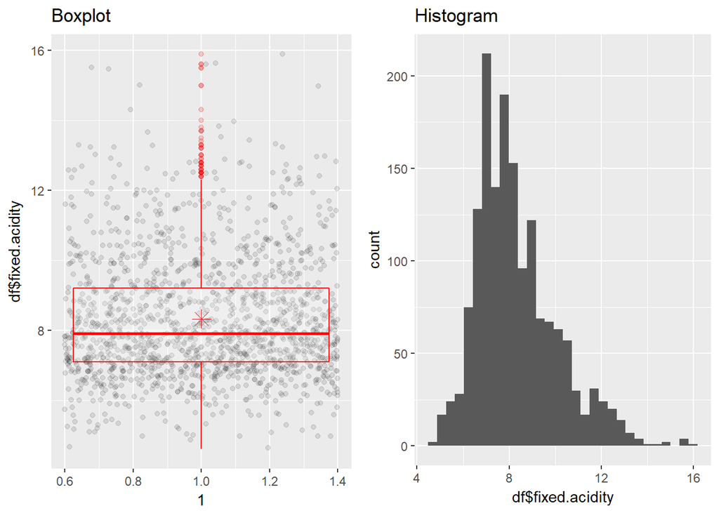

```
##    Min. 1st Qu.  Median    Mean 3rd Qu.    Max.
##    4.60    7.10    7.90    8.32    9.20   15.90
```

Fixed acidity has outliers from 12.5 to 16. The mean is higher than the median due to the presence of outliers. The range of fixed acidity is 11.3.

### Volatile Acidity

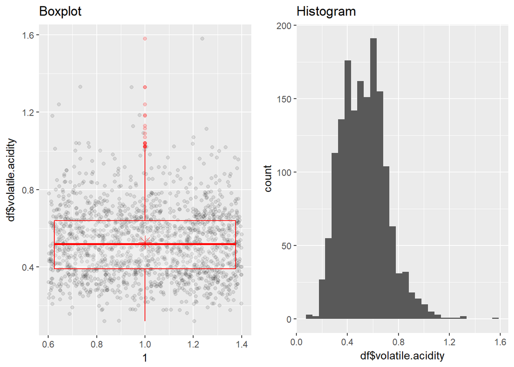

```
##    Min. 1st Qu.  Median    Mean 3rd Qu.    Max.
##  0.1200  0.3900  0.5200  0.5278  0.6400  1.5800
```

Volatile acidity refers to the amount of acetic acid in wine, which at too high of levels can lead to an unpleasant, vinegar taste. From the box plot, I can see outliers in the higher end which are probably of low quality.

### Citric Acid

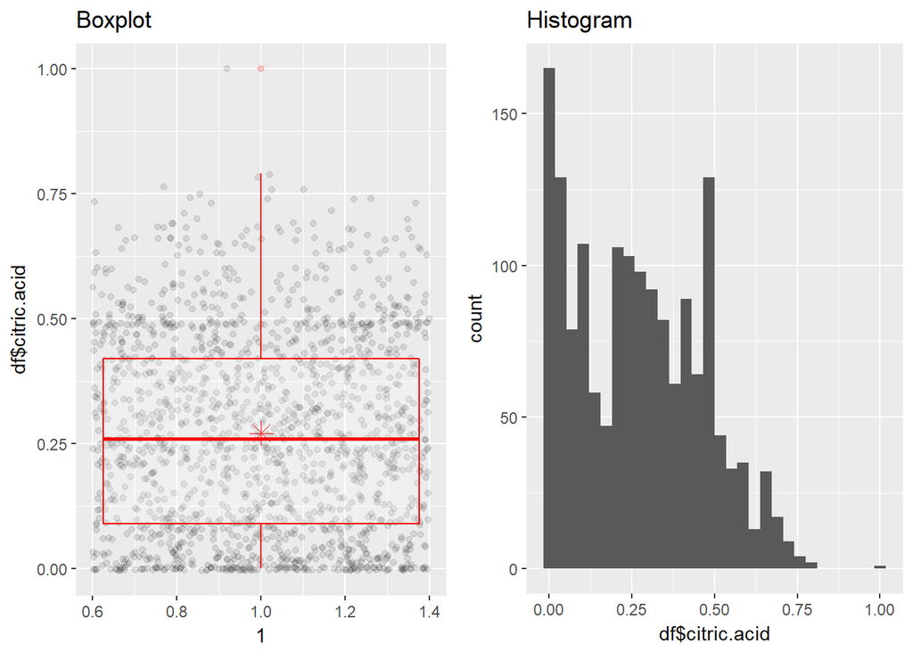

```
##    Min. 1st Qu.  Median    Mean 3rd Qu.    Max.
##   0.000   0.090   0.260   0.271   0.420   1.000
```

Citric acid has a single outlier with a value of 1 g / dm^3 which probably has the maximum ‘freshness’ among the wines in this data set. There are a large number of wines with citric acid value as 0 g / dm^3. Most wines in the data set have citric acid value in the range of 0 to 0.5.

### Free sulfur dioxide

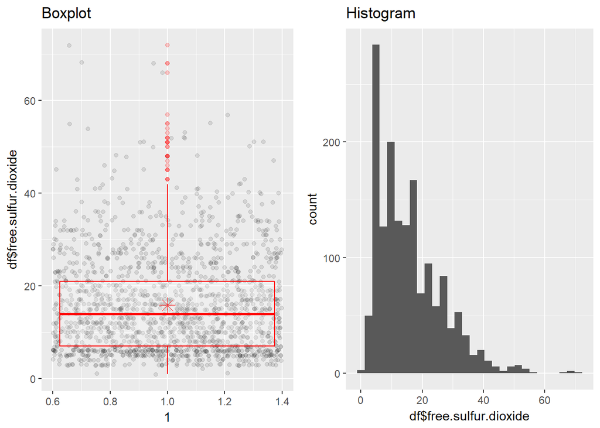

```
##    Min. 1st Qu.  Median    Mean 3rd Qu.    Max.
##    1.00    7.00   14.00   15.87   21.00   72.00
```

Free sulfur dioxide prevents microbial growth and the oxidation of wine. Outliers of sulfur dioxide start from a value of about 45mg / dm^3 and extend up to a maximum of 72mg / dm^3. These are probably of good quality as they prevent microbial growth.

### Total sulfur dioxide

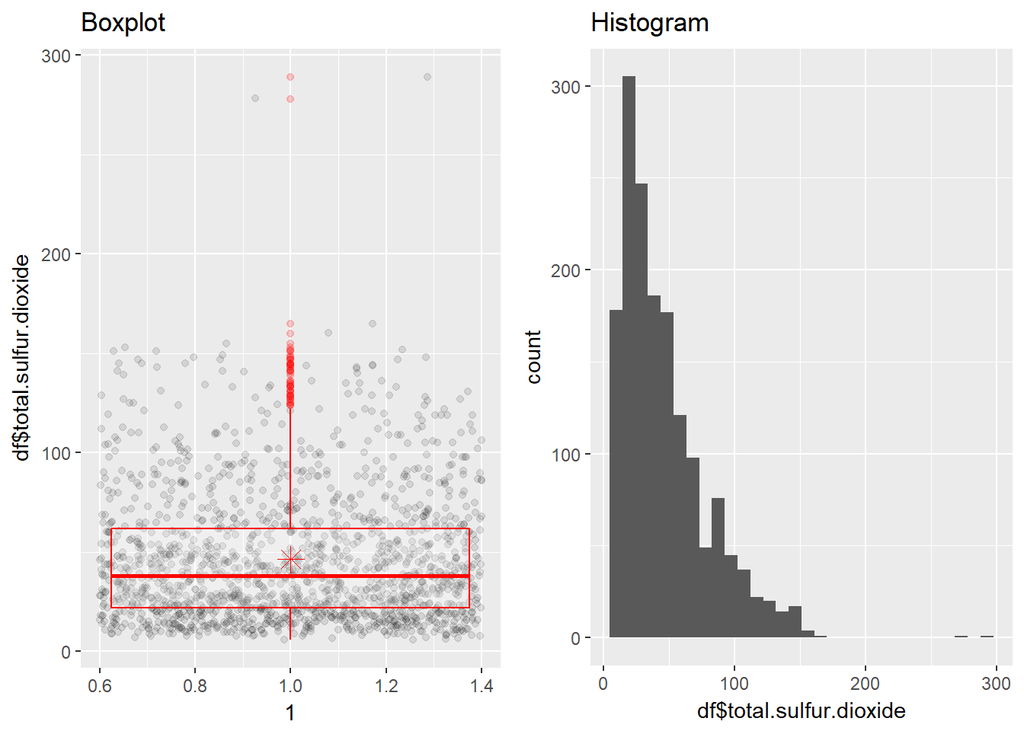

```
##    Min. 1st Qu.  Median    Mean 3rd Qu.    Max.
##    6.00   22.00   38.00   46.47   62.00  289.00
```

```
## [1] 32.89532
```

Total sulfur dioxide is the amount of free and bound forms of S02; in low concentrations, SO2 is mostly undetectable in wine, but at free SO2 concentrations over 50 ppm, SO2 becomes evident in the nose and taste of wine.

There are 2 outliers which are more than 6 standard deviations away from the mean. The other outliers are concentrated in the 125mg / dm^3 to 175mg / dm^3 region. As total SO2 includes free SO2, I wonder if the 2 extreme outliers are the same ones found on the higher end of free sulfur dioxide boxplot.

```
##         X fixed.acidity volatile.acidity citric.acid residual.sugar
## 397   397           6.6            0.735        0.02            7.9
## 401   401           6.6            0.735        0.02            7.9
## 1245 1245           5.9            0.290        0.25           13.4
##      chlorides free.sulfur.dioxide total.sulfur.dioxide density   pH
## 397      0.122                  68                  124 0.99940 3.47
## 401      0.122                  68                  124 0.99940 3.47
## 1245     0.067                  72                  160 0.99721 3.33
##      sulphates alcohol quality
## 397       0.53     9.9       5
## 401       0.53     9.9       5
## 1245      0.54    10.3       6
```

```
##         X fixed.acidity volatile.acidity citric.acid residual.sugar
## 1080 1080           7.9              0.3        0.68            8.3
## 1082 1082           7.9              0.3        0.68            8.3
##      chlorides free.sulfur.dioxide total.sulfur.dioxide density   pH
## 1080      0.05                37.5                  278 0.99316 3.01
## 1082      0.05                37.5                  289 0.99316 3.01
##      sulphates alcohol quality
## 1080      0.51    12.3       7
## 1082      0.51    12.3       7
```

The first data frame belongs to the outliers of free SO2 and the second to that of total SO2. Looking at the data frames, we find that they are different.

### Density

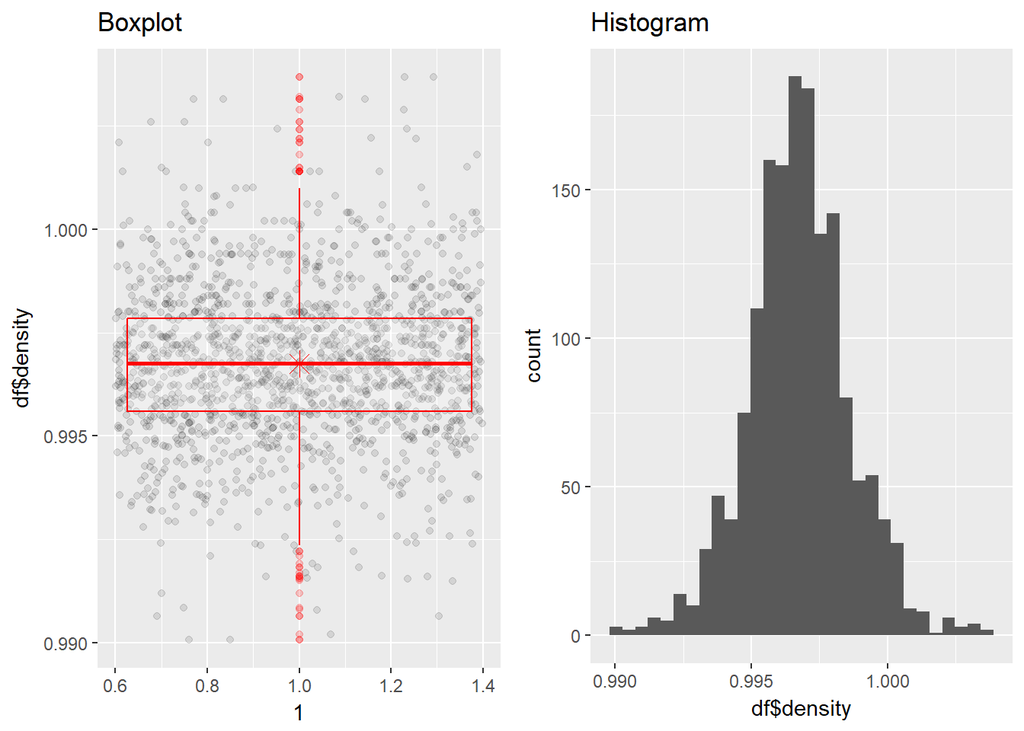

```
##    Min. 1st Qu.  Median    Mean 3rd Qu.    Max.
##  0.9901  0.9956  0.9968  0.9967  0.9978  1.0037
```

The plot for density has outliers on both ends. The plot looks almost symmetric with a small range of 0.0136.

### pH

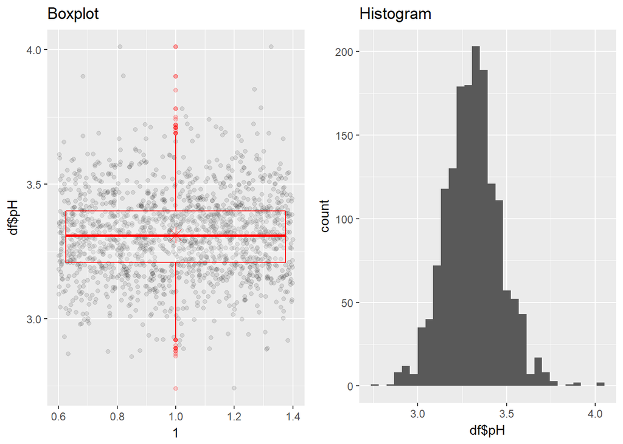

```
##    Min. 1st Qu.  Median    Mean 3rd Qu.    Max.
##   2.740   3.210   3.310   3.311   3.400   4.010
```

pH describes how acidic or basic a wine is on a scale from 0 (very acidic) to 14 (very basic). Most wines are between 3-4 on the pH scale. The plot looks symmetric. There are outliers on both ends.

### Sulphates

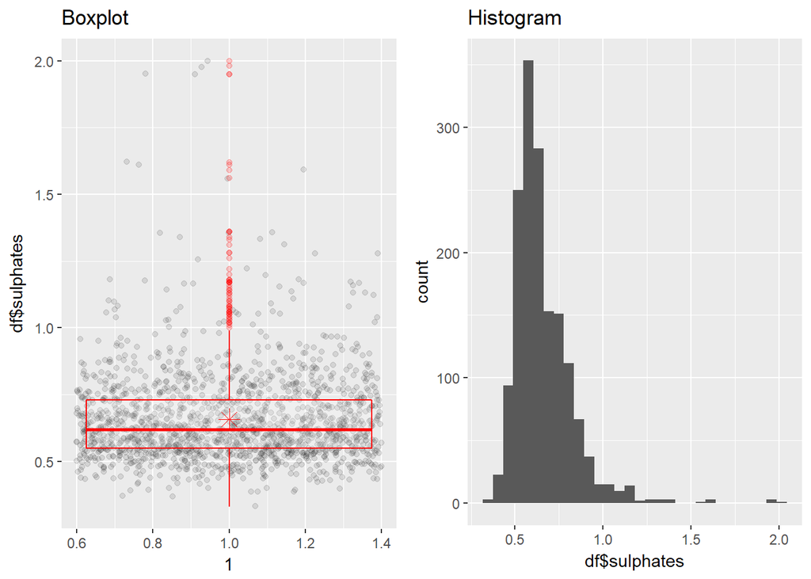

```
##    Min. 1st Qu.  Median    Mean 3rd Qu.    Max.
##  0.3300  0.5500  0.6200  0.6581  0.7300  2.0000
```

Sulphate is a wine additive which can contribute to sulfur dioxide gas (S02) levels, which acts as an antimicrobial and antioxidant. The wines with higher sulphate concentration probably belong to better quality. The range of sulphates is 1.67. A large number of outliers are present between 1g / dm^3 and 2g / dm^3.

### Alcohol

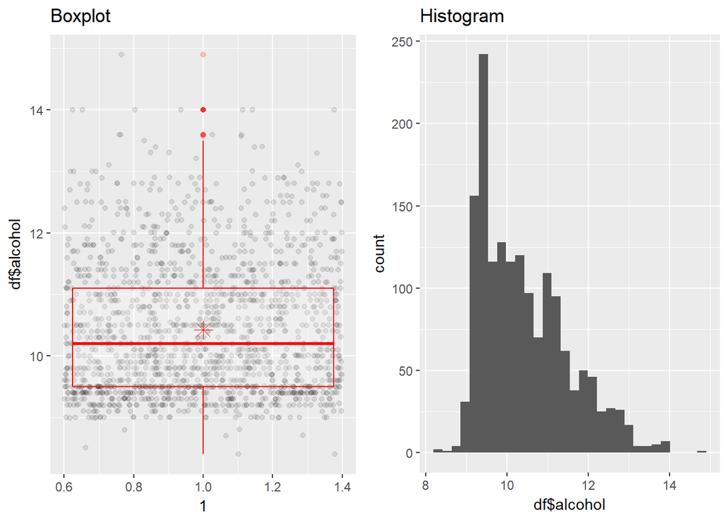

```
##    Min. 1st Qu.  Median    Mean 3rd Qu.    Max.
##    8.40    9.50   10.20   10.42   11.10   14.90
```

The outliers of alcohol lie between 13.5 and 14.9. A large number of wines have an alcohol of around 9.4% by volume.

### Residual Sugar

As the histogram of residual sugar has a very long tail, I have removed the outliers.

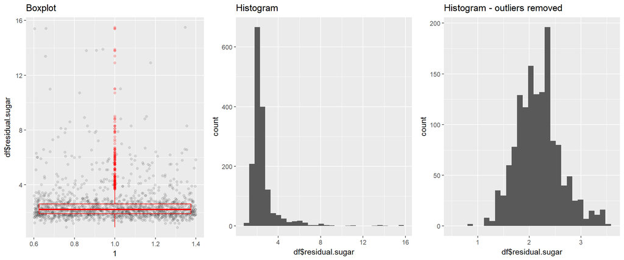

Residual sugar is the amount of sugar remaining after fermentation stops. It’s rare to find wines with less than 1 gram/liter and wines with greater than 45 grams/liter are considered sweet. There are 2 wines which have residual sugar less than 1 gram/liter in this data set.

```
##    Min. 1st Qu.  Median    Mean 3rd Qu.    Max.
##   0.900   1.900   2.200   2.539   2.600  15.500
```

```
##         X fixed.acidity volatile.acidity citric.acid residual.sugar
## 1018 1018             8             0.18        0.37            0.9
## 1019 1019             8             0.18        0.37            0.9
##      chlorides free.sulfur.dioxide total.sulfur.dioxide density   pH
## 1018     0.049                  36                  109 0.99007 2.89
## 1019     0.049                  36                  109 0.99007 2.89
##      sulphates alcohol quality
## 1018      0.44    12.7       6
## 1019      0.44    12.7       6
```

There are no wines in this data set which have residual sugar value greater than 45 grams/liter.

### Chlorides

Chlorides also have a very long tail and hence the outliers have been removed.

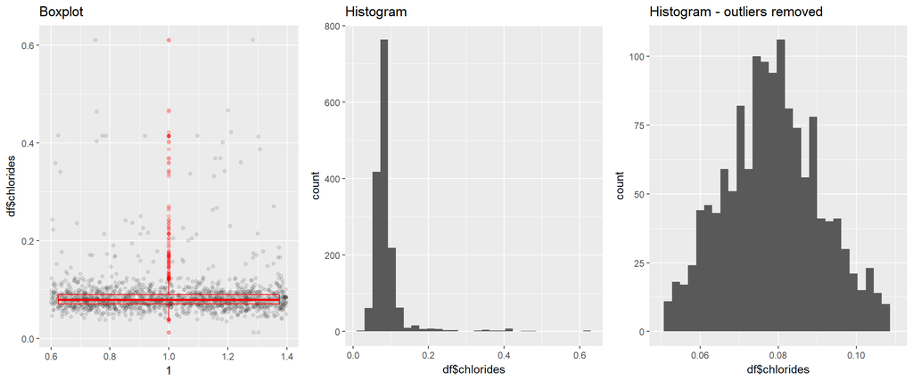

```
##    Min. 1st Qu.  Median    Mean 3rd Qu.    Max.
## 0.01200 0.07000 0.07900 0.08747 0.09000 0.61100
```

```
## [1] 0.02
```

Chlorides refer to the amount of salt in the wine. We see that there are a large number of outliers in the boxplot. After removing the outliers, the distribution looks normal.

# Univariate Analysis

### What is the structure of your dataset?

There are 1599 red wines in the data set with 11 variables on the chemical properties of the wine(fixed acidity, volatile acidity, citric acid, residual sugar, chlorides, free sulfur dioxide, total sulfur dioxide, density, pH, suphates, alcohol) and 1 output variable quality which is based on sensory data. The variable ‘quality’ is an ordered factor variable. It can have a score between 0 and 10 with 0 being the least and 10 being the highest.

Other observations:

- Quality of all wines given in the data set fall within the range of 3 to 8.
- Maximum number of wines are of quality 5.
- A significant number of wines have 0 citric acid in them.
- Maximum alcohol content is 14.9 % by volume.
- Maximum volatile acidity is 1.58 g / dm^3.

### What is/are the main feature(s) of interest in your dataset?

The main feature of interest in this data set is quality. I’d like to determine features which are best for predicting the quality of red wine.

### What other features in the dataset do you think will help support your investigation into your feature(s) of interest?

Volatile acidity, citric acid, residual sugar, free sulfur dioxide, total sulfur dioxide, sulphates and alcohol are likely to contribute to the quality of wines.

### Did you create any new variables from existing variables in the dataset?

Yes. In the multivariate plots section, ‘fixed.acidity.cut’ and ‘pH.cut’ were created based on the existing ‘fixed.acidity’ and ‘pH’ variables respectively .

# Bivariate Plots Section

The correlation between pairs of variables in the data set needs to be analyzed.

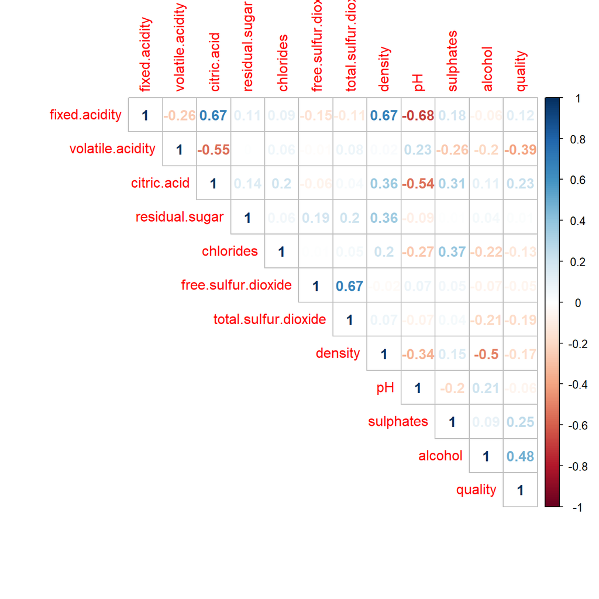

We shall use scatter plots to explore the pattern of the variables.

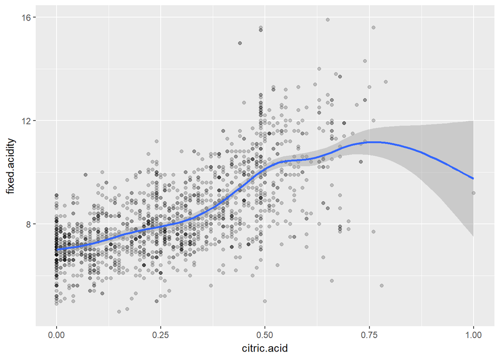

As citric acid increases, fixed acidity also increases.There is an outlier having citric acid value of 1g / dm^3.

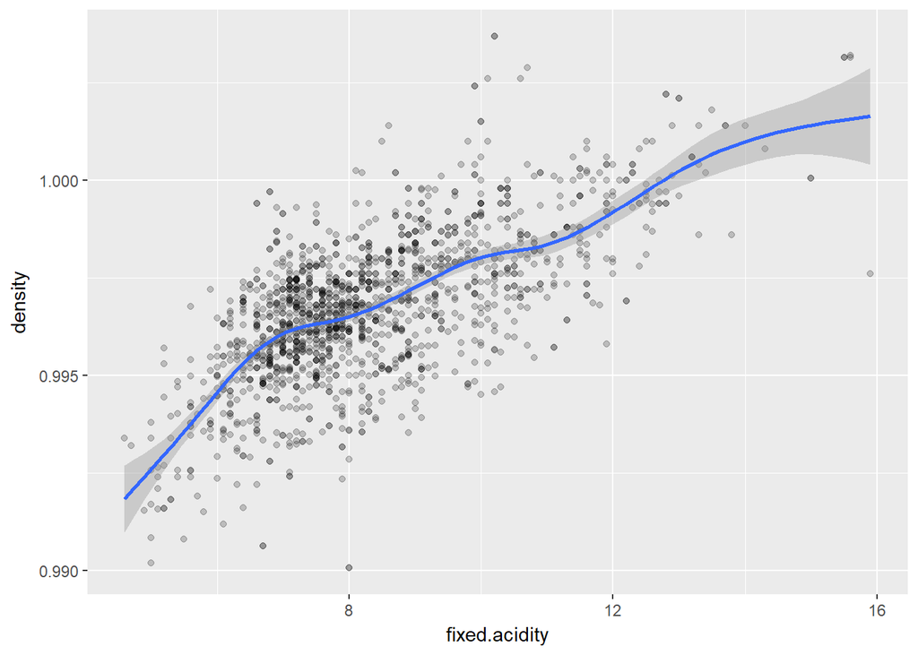

Density increases with increase in fixed acidity. Most of the wines have fixed acidity of 6g / dm^3 to 10g / dm^3 and density of 0.9925g / cm^3 to 1g / cm^3.

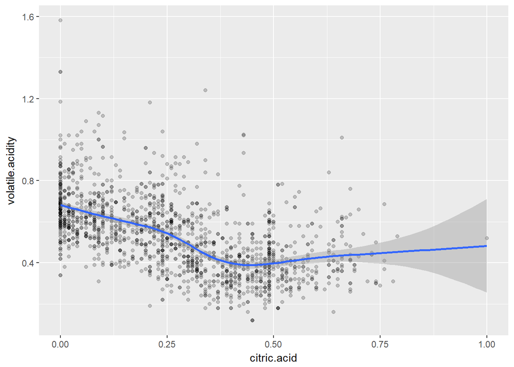

Volatile acidity decreases with increase in citric acid till 0.375g / dm^3 which is within the third quartile of citric acid(0.42g / dm^3). Therefore for majority of red wines, volatile acidity decrease with increase in citric acid.

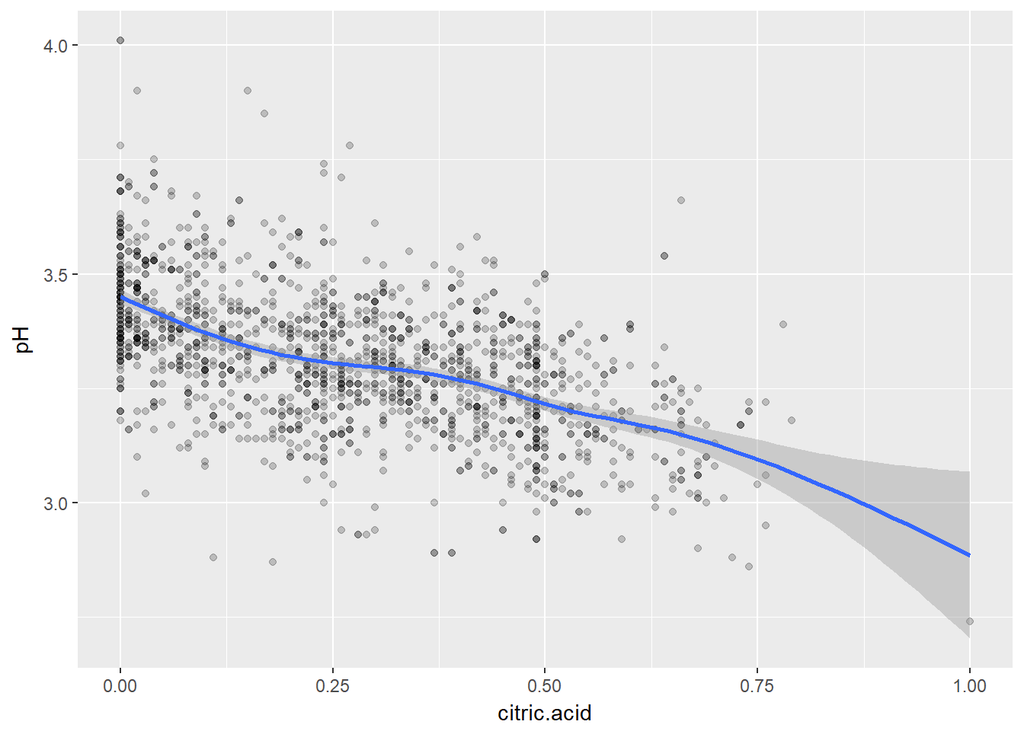

As we expect, pH decreases with increase in citric acid.

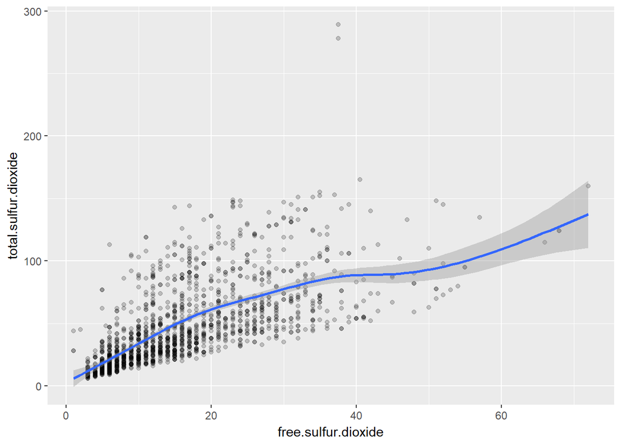

Total sulfur dioxide increases with increase in free sulfur dioxide. A large number of wines have free SO2 value less than 20mg / dm^3 and total SO2 less than 100mg / dm^3.

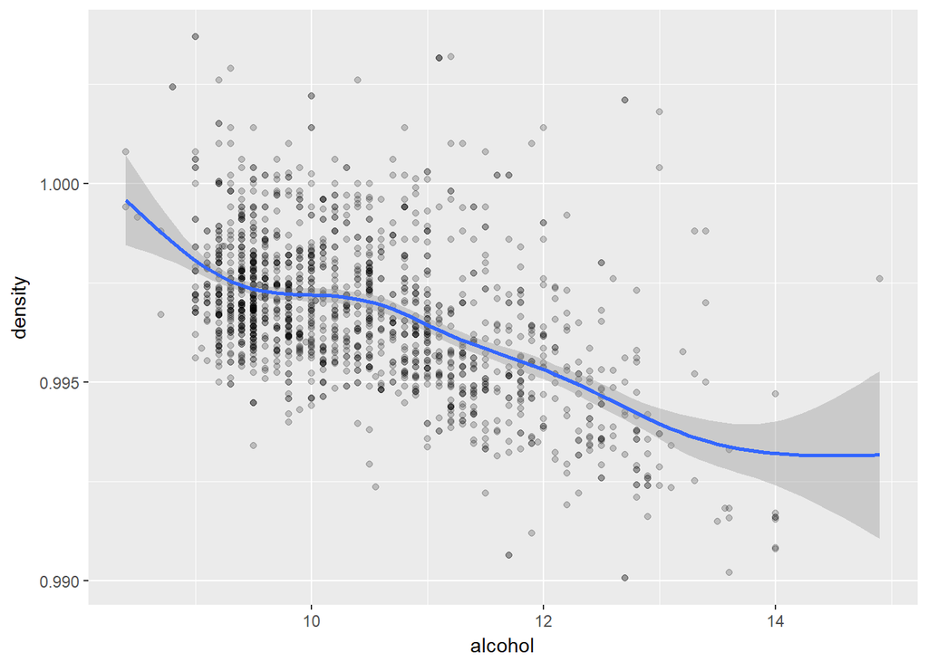

As alcohol increases, density decreases.

#### The strongest relationship:

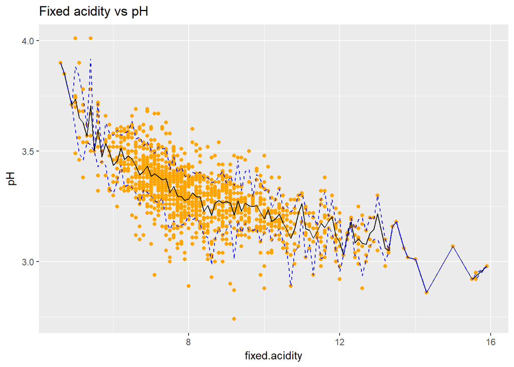

In the fixed acidity vs pH plot, dotted lines represent 0.1 and 0.9 quantiles. The black line indicates the mean. We can see that pH decreases with increase in fixed acidity. Majority of the wines lie between 6 g/dm^3 and 10 g/dm^3 of fixed acidity and 3 to 3.75 pH.

#### Analysis of variables with respect to quality

The relation between quality and other variables is examined by plotting the box and jitter plots of the variables with respect to quality.

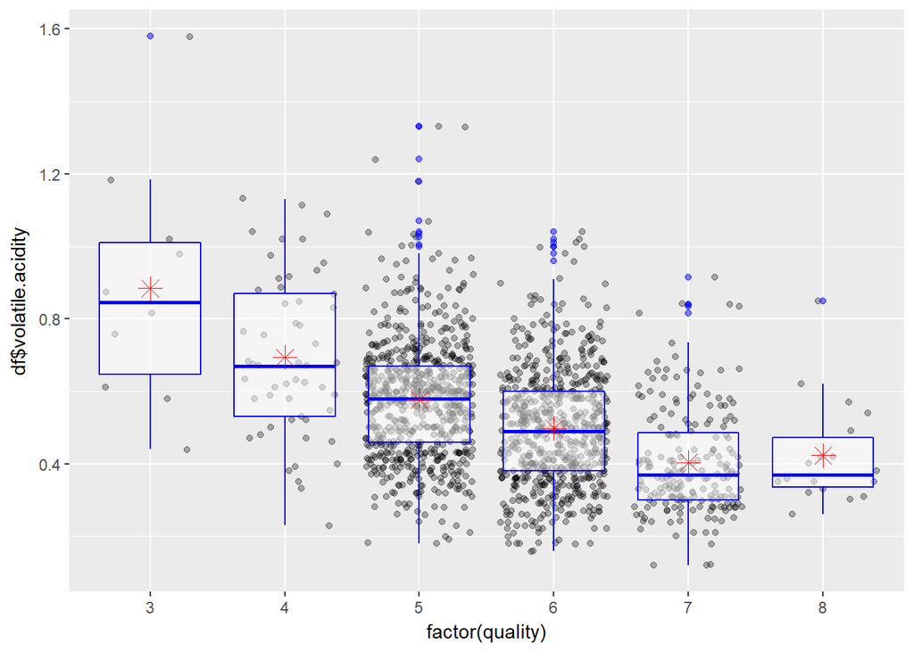

As expected, high quality wines have low volatile acidity and low quality wines have high volatile acidity.

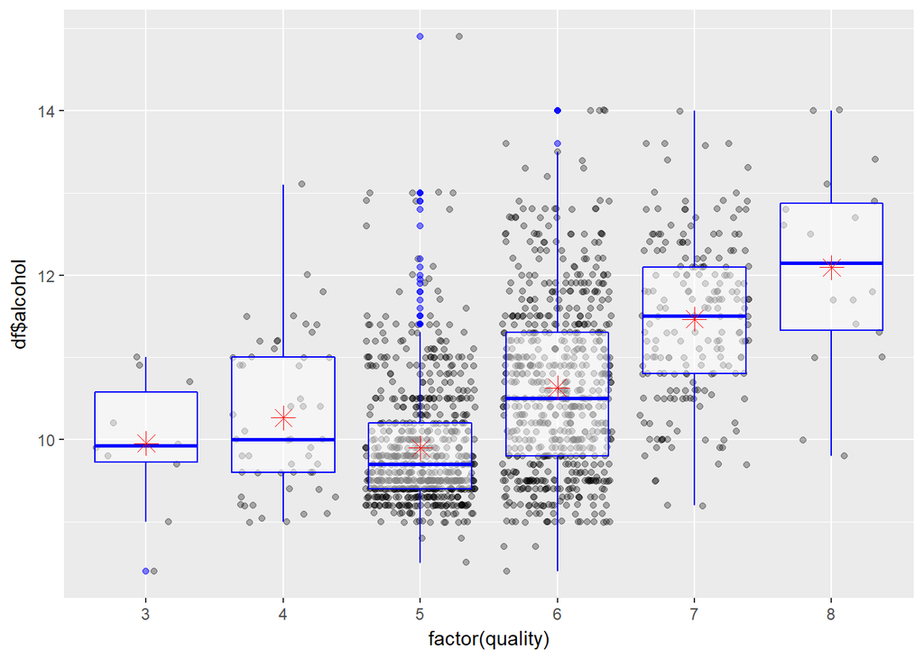

High quality wines have higher alcohol content than low quality wines.

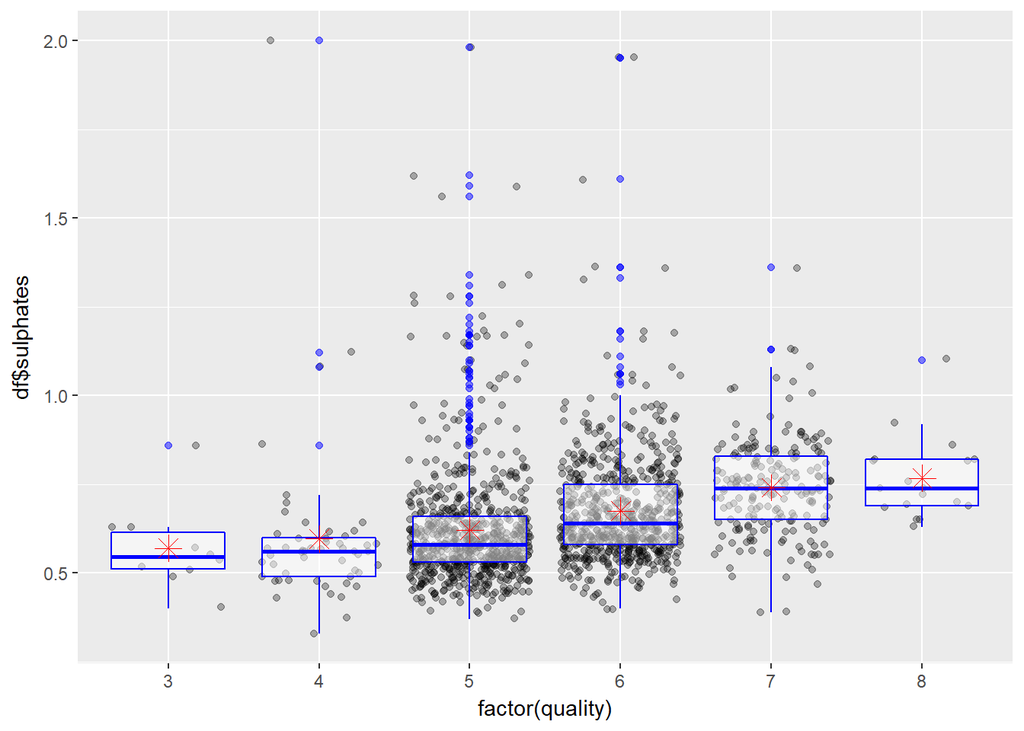

High quality wines seem to have slightly higher sulphate content than low quality wines.

# Bivariate Analysis

### Talk about some of the relationships you observed in this part of the investigation. How did the feature(s) of interest vary with other features in the dataset?

As expected, quality increased with decrease in volatile acidity. This is because volatile acidity can cause an unpleasant, vinegar taste at high levels. Quality also increased with increase in alcohol. High quality wines had slightly higher amount of sulphates than low quality wines. This may be because sulphates can contribute to sulfur dioxide gas (S02) levels, which acts as an antimicrobial and antioxidant.

# Multivariate Plots Section

#### Alcohol vs volatile acidity by quality category

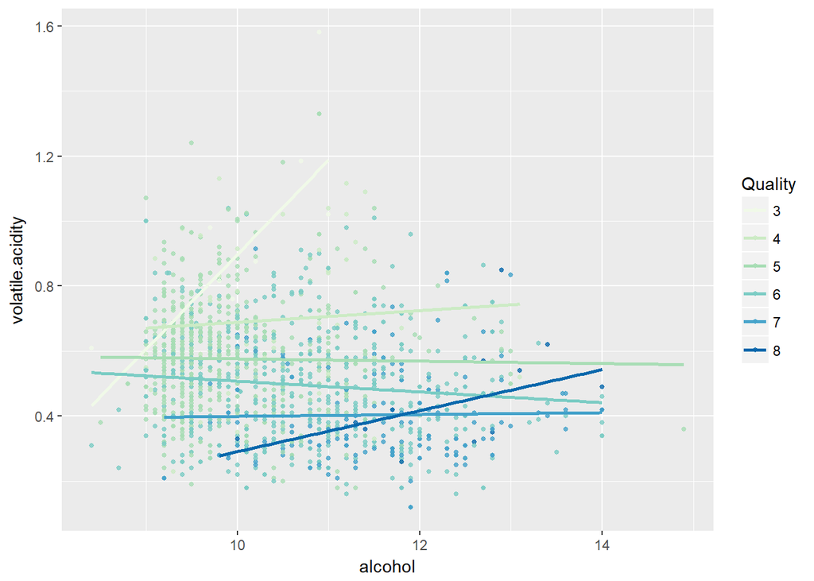

Here we see that poor quality wines have less alcohol and higher volatile acidity than better quality wines. Excellent quality wines have low volatile acidity and higher alcohol content.

#### Citric acid vs density by fixed acidity

Let us create buckets for fixed acidity and obtain a scatter plot.

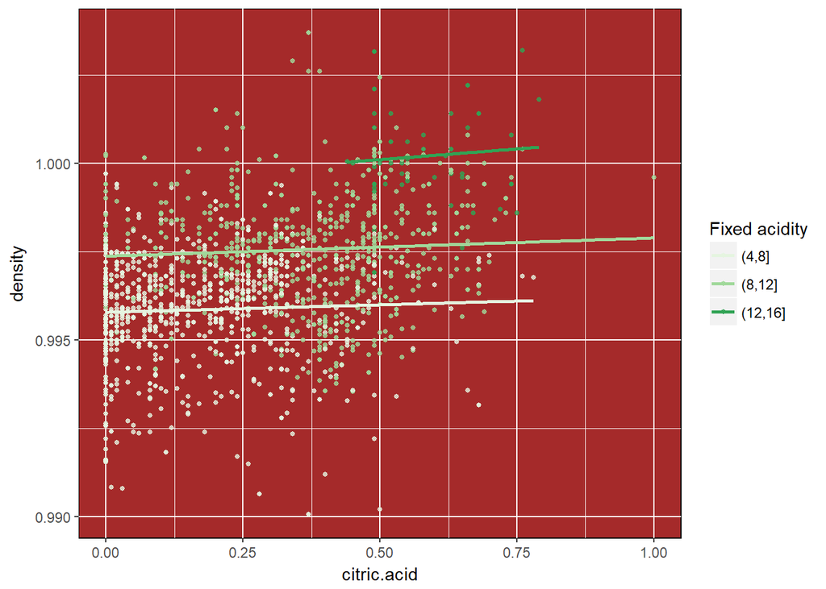

The above plot gives the relation among citric acid, density and fixed acidity. We can see that with each increasing bucket of fixed acidity, the density is also increasing. The highest fixed acidity bucket has the highest density values. It also has high citric acid values. We also note that there is increase in density with citric acid.

#### Citric acid vs pH by fixed acidity

Below is the scatter plot using buckets for fixed acidity.

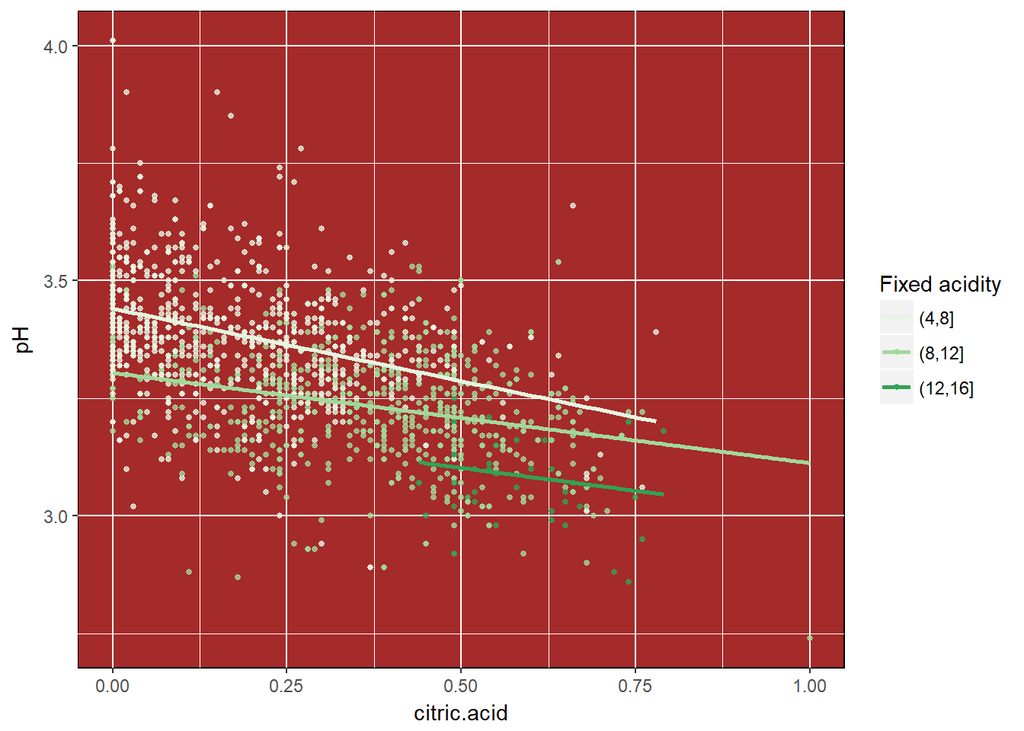

With each increasing bucket of fixed acidity, pH is decreasing. Wines with low citric acid have low fixed acidity. Wines with high fixed acidity have high citric acid content. With increase in citric acid, we observe a decrease in pH.

#### Analysis of the relationship among Fixed acidity, Citric acid, Density and pH

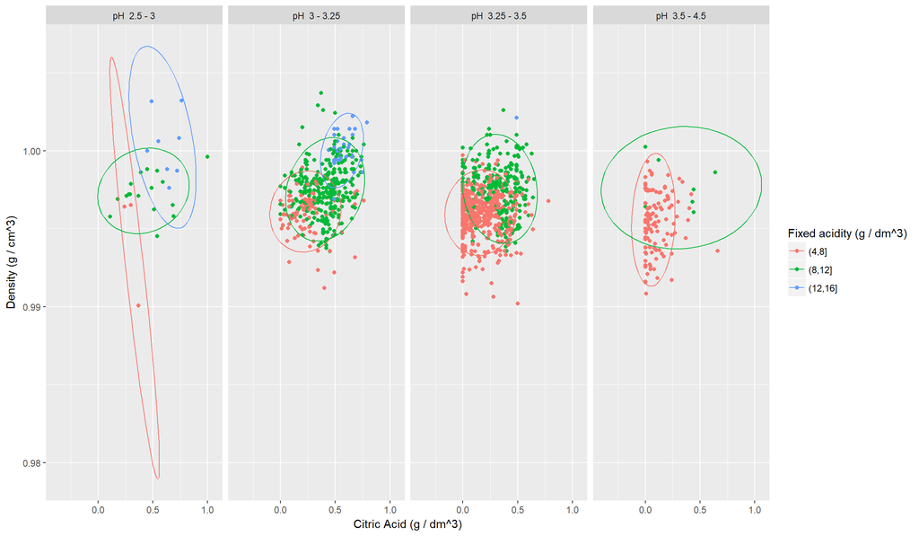

We infer from the plot that, fixed acidity is high when citric acid and density are high and pH is low. Similarly fixed acidity is low when citric acid and density are low and pH is high.

# Multivariate Analysis

### Talk about some of the relationships you observed in this part of the investigation. Were there features that strengthened each other in terms of looking at your feature(s) of interest?

It was observed that a combination of high alcohol content and low volatile acidity contributed to better quality of wine. Fixed acidity increased with increase in citric acid and density while decreased with pH. Maximum fixed acidity is found in the region with high citric acid, high density and low pH.

# Final Plots and Summary

### Plot One

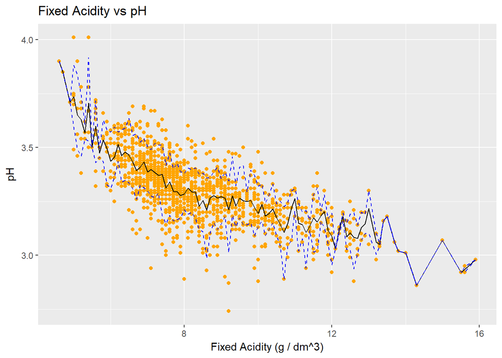

### Description One

In the fixed acidity vs pH plot, dotted lines represent 0.1 and 0.9 quantiles. The black line indicates the mean. We can see that pH decreases with increase in fixed acidity. Majority of the wines lie between 6 g/dm^3 and 10 g/dm^3 of fixed acidity and 3 to 3.75 pH.

### Plot Two

[figure not shown]

### Description Two

Here we see that poor quality wines have less alcohol and higher volatile acidity than better quality wines. Excellent quality wines have low volatile acidity and higher alcohol content.

### Plot Three

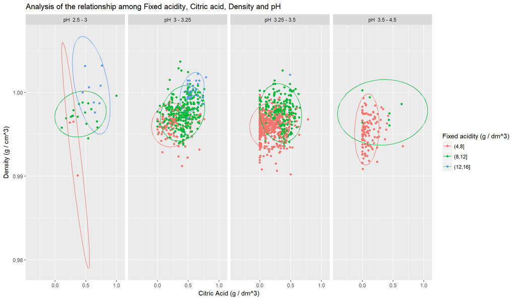

### Description Three

We infer from the plot that, fixed acidity is high when citric acid and density are high and pH is low. Similarly fixed acidity is low when citric acid and density are low and pH is high.

# Reflection

I started by analyzing variables individually(univariate analysis) by plotting histograms and boxplots. Then in the bivariate analysis I was able to obtain relationships between pairs of variables. I found that the primary feature ‘quality’ significantly correlated only with alcohol and volatile acidity. This was surprising as I expected significant amount of correlation with other factors like citric acid, free sulfur dioxide, and sulphate also.

The main difficulty I had with this data set was that I was not familiar with properties of red wine. So my intuitions were purely based on the description given. I was able to understand the properties better after starting with the analysis. In the multi-variate analysis, I was able to analyze 4 variables to determine the relationship between them and identify the combination which results in maximum fixed acidity.

The analysis could be improved if the data set includes wines belonging to all the qualities(0-10) instead of just 3-8.